# Seattle vs Boston - Battle of the Cities

[figure not shown]

# 1. The average price that is charged in relation to the location of the listings

### Overview

The question that is on everyones lips, where is all the attractions at? How far am I from them and would I get value for money. In this analysis we looked at the physical locations of each of the listings on AirBnB for two Cities (Seattle and Boston). From the analysis the following is clear:

1. The average listing price that is paid per night in Boston is higher than Seattle
2. The number of visits per neighborhood in Boston is more than in Seattle
3. There are more listings are available in Seattle than in Boston

### Seattle

1. \$ 111 is the average price charged and the average number of visits per property is 1000 these properties are indicated by the orange markers, and they fall around the main attractions is Seattle
2. For listings where the price is below the average price, but have higher than average visits - regarded as cheaper is marked in purple
3. The green markers show the rest of the group that fall outside of the criteria stipulated above, these indicate lower that the average 1000 visits

### Boston

1. \$ 167 is the average price charged and the average number of visits per property is 2095 these properties are indicated by the orange markers
2. For listings where the price is below the average price, but have higher than average visits - regarded as cheaper is marked in purple, these listings are on the outskirts of Boston
3. The green markers show the rest of the group that fall outside of the criteria stipulated above, these indicate lower that the average 2095 visits

```
        listing_id       price
count    80.000000   80.000000
mean   1002.375000  111.286937
std    1572.224026   47.607750
min       1.000000   59.013158
25%     146.500000   84.848797
50%     389.000000  103.318092
75%    1150.750000  125.564888
max    8703.000000  370.000000
```

[interactive chart not shown]

```
        listing_id       price
count    29.000000   29.000000
mean   2095.551724  167.500324
std    2372.827993   84.069476
min       2.000000   55.182432
25%     106.000000  101.710428
50%     954.000000  159.217370
75%    4099.000000  210.720149
max    8644.000000  355.982143
```

[interactive chart not shown]

# 2. The description on the listings

## Overview

The reason why someone would want to rent an property is greatly dependent on the description that is provided by the owners. The initial advertisement of the property can generate a lot of hits, that could potentially lead to successful rentals. The analysis look at how properties are described.

There is vastly different descriptions provided between the two cities, this can be potentially prescribed to what the prospective renters are looking at when visiting a specific destination.

## Seattle

1. Seattle offer a wide range of properties and therefore the market will be more competitive
2. Descriptions of properties is more extensive that compared to Boston, speaking more about the property itself that the location

## Boston

1. As mentioned before description of the property speak more to the location than to the property itself, this could be due to less competition in the market

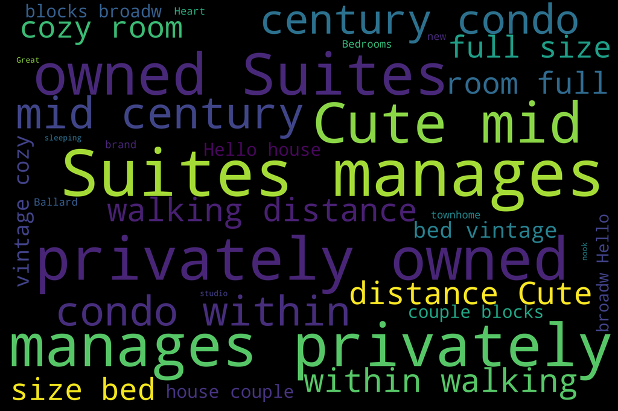

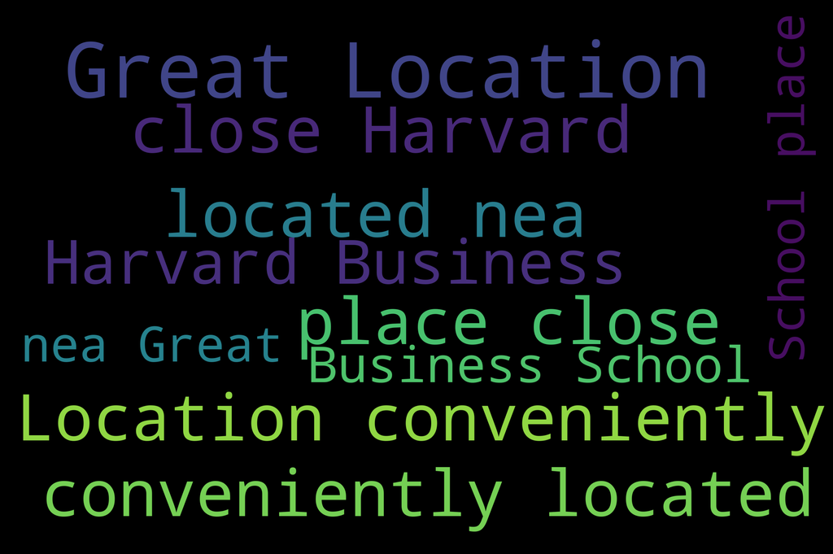

# 3. What is the general feedback from the guests by city and how their stay is experienced

## Overview

Sentiment forms a big part in the overall experience of a guest, and looking at the feedback that is provided can be valuable. For this piece of work sentiment analysis was performed to look at the feedback of the guests, between the two cities. Based on this owners can decide to make some improvements to their property for then to stand out from a competitor. The boxplots below demonstrate the sentiments of the guests.

## Outcome

### Negative sentiment

1. Boston seem to have less negative feedback, having less visitors can contribute to this.

### Neutral

1. The feedback on Boston seem to be a bit more neutral than compared to Seattle

### Positive

1. Seattle seem to have more positive feedback that Boston

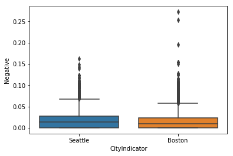

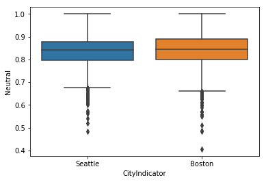

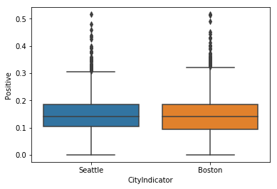

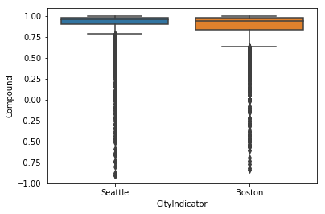

# Conclusion

We see that there is a lot more listings in Seattle compared to Boston, Seattle could be a better tourist attraction. With the competitions in Seattle being more the average price is significantly less.